# WQD7004_Group_Project_G6

-

-

# WQD7004 Programming for Data Science

#### Lecturer: Assoc. Prof. Dr. Ang Tan Fong

## Group Project - Group 6

### Group Members:

- Chen Yayi (S2110521)
- Cheng Ziyu (17141946)
- Lee Voon Chung (S2142277)
- Lee Voon Hee (S2140816)
- Leow Jun Shou (17123313)

# Predicting the Risk of Company Bankruptcy Using Financial Indicators

## Table of Contents

1. Introduction  
2. Research Questions  
3. Research Objectives  
4. Description of Dataset  
5. Data Cleaning and Pre-Processing  
- 5.1 Preview of Dataset  
- 5.2 Removing Columns with Percentage of NA’s > 10%  
- 5.3 Heat Map of Correlation Coefficients between Attributes & Retaining One (1) Attribute from Each Highly Correlated Group  
- 5.4 Exploratory Data Analysis (EDA)  
- 5.5 Imputation for Columns with Percentage of NA’s 1% to 10%  
- 5.6 Removing Rows for Columns with Percentage of NA’s < 1%  
6. Tidy Dataset, Z-Score Normalisation, Data Partition & SMOTE  
- 6.1 Tidy Dataset  
- 6.2 Data Transformation with Z-Score Normalisation  
- 6.3 Data Partition  
- 6.4 Oversampling & Undersampling with SMOTE  
7. Modelling  
- 7.1 Random Forest Classification Analysis  
- 7.2 k-Nearest Neighbours Classification Analysis  
- 7.3 AdaBoost Classification Analysis  
- 7.4 Logistic Regrssion Analysis  
- 7.5 Identifying Important Financial Ratios Associated with Bankruptcy through Logistic Regression Model  
8. Results  
9. Conclusions  
References

## 1. Introduction

According to Cambridge Dictionary (Cambridge University Press, 2022), **bankruptcy** refers to a situation in which a business or a person becomes unable to pay what is owed.

There are subtle differences across countries on the legal definition of company bankruptcy. In layman’s terms, when a company declares bankruptcy, the company is unable to pay off its debts when they fall due – it will cease its business operation and eventually have to liquidate its assets.

Company bankruptcies are often associated with monetary loss to shareholders and creditors. Moreover, cessation of business operation would mean leaving a void in the supply chain, thus causing disruption to the downstream and upstream businesses, and ultimately to the public consumers of those goods and services. In 2008, the bankruptcy of Lehman Brothers had even initiated a ripple effect to the entire financial industry, leading to the 2008 Global Financial Crisis which adversely affected other non-financial industries and economies of various countries. The infamous multinational insurance group – the American International Group (AIG) was adversely affected by the spill-over turmoil to the extent that it had to be bailed out by the US government (Financial Crisis Inquiry Commission, 2011).

Given the negative consequence of company bankruptcies, attempts have been made to predict company bankruptcies using traditional regression-type classification analysis based on companies’ financial ratios as early as 1968 (Altman, 1968). In the study, the author separated various financial ratios of companies derived from their balance sheet and income statement into five categories, namely liquidity ratio, profitability ratio, leverage ratio, solvency ratio, and activity ratios. In recent years, with the development of new analysis techniques and increasing computing power, machine learning techniques have been utlised to tackle company bankruptcy prediction problem (Wang & Liu, 2021).

For this Group Project, a dataset comprising **Polish companies bankruptcy status** alongside their financial ratios were found on the Internet (Tomczak, 2016). Using this dataset, we intend to achieve our research objectives and answer the research questions below.

## 2. Research Questions

1. How is the performance of logistic regression and other machine learning classification models in predicting company bankruptcy?
2. Which financial ratios are important in predicting bankruptcy status of Polish companies?

## 3. Research Objectives

1. To build various logistic regression and machine learning classification models.
2. To compare prediction accuracies of models.
3. To identify the top five most important financial ratios associated with bankruptcy from logistic regression model.

## 4. Description of Dataset

There are five “.arff” files/ datasets in Tomczak (2016). In order to simplify the whole process, only “**3year.arff**” will be pre-processed and analysed in this project as it contains the greatest number of records (i.e. rows) among all the five files.

- “1year.arff” contains financial indicators on 1st year of the forecasting period and the bankruptcy status after 5 years. This file contains 7027 companies (financial statements), 271 went bankrupt after 5 years while 6756 did not bankrupt in the forecasting period.
- “2year.arff” contains financial indicators on 2nd year of the forecasting period and the bankruptcy status after 4 years. This file contains 10173 companies (financial statements), 400 went bankrupt after 4 years while 9773 did not bankrupt in the forecasting period.
- **“3year.arff” contains financial indicators on 3rd year of the forecasting period and the bankruptcy status after 3 years. This file contains 10503 companies (financial statements), 495 went bankrupt after 3 years while 10008 did not bankrupt in the forecasting period.**
- “4year.arff” contains financial indicators on 4th year of the forecasting period and the bankruptcy status after 2 years. This file contains 9792 companies (financial statements), 515 went bankrupt after 2 years while 9277 did not bankrupt in the forecasting period.
- “5year.arff” contains financial indicators on 5th year of the forecasting period and the bankruptcy status after 1 year. This file contains 5910 companies (financial statements), 410 went bankrupt after 1 year while 5500 did not bankrupt in the forecasting period.

**Tables 4.1** and **4.2** below show the general details of the of the dataset “3year.arff”. The derivation of dataset dimensions, minimum and maximum values for each column, and number and percentage of missing values will be demonstrated in **Section 5**.

**Table 4.1**: Description of dataset “3year.arff”

| Detail | Description |
| --- | --- |
| Title: | Polish companies bankruptcy data |
| Source: | Tomczak, S. K. (2016). UCI Machine Learning Repository. |
| Link: | https://archive.ics.uci.edu/ml/datasets/Polish+companies+bankruptcy+data |
| Years: | 2000 - 2013 |
| Purpose: | The dataset is about bankruptcy prediction of Polish companies. The bankrupt companies were analysed in the period 2007 to 2013, while the still operating companies were evaluated from 2000 to 2012. |
| Filename: | 3year.arff |
| Number of rows: | 10503 rows |
| Number of columns: | 65 columns |

**Table 4.2**: Contents of dataset “3year.arff”

| Column Name | Column Description from Metadata | Data Type | Min | Max | Number of NA’s | Percentage of NA’s (%) |
| --- | --- | --- | --- | --- | --- | --- |
| Attr1 | X1 net profit / total assets | Numeric | -17.692 | 52.652 | 0 | 0 |
| Attr2 | X2 total liabilities / total assets | Numeric | 0 | 480.73 | 0 | 0 |
| Attr3 | X3 working capital / total assets | Numeric | -479.73 | 17.708 | 0 | 0 |
| Attr4 | X4 current assets / short-term liabilities | Numeric | 0.00208 | 53433 | 18 | 0.17 |
| Attr5 | X5 [(cash + short-term securities + receivables - short-term liabilities) / (operating expenses - depreciation)] * 365 | Numeric | -11903000 | 685440 | 25 | 0.24 |
| Attr6 | X6 retained earnings / total assets | Numeric | -508.12 | 45.533 | 0 | 0 |
| Attr7 | X7 EBIT / total assets | Numeric | -17.692 | 52.652 | 0 | 0 |
| Attr8 | X8 book value of equity / total liabilities | Numeric | -2.0818 | 53432 | 14 | 0.13 |
| Attr9 | X9 sales / total assets | Numeric | -1.2157 | 740.44 | 3 | 0.03 |
| Attr10 | X10 equity / total assets | Numeric | -479.73 | 11.837 | 0 | 0 |
| Attr11 | X11 (gross profit + extraordinary items + financial expenses) / total assets | Numeric | -17.692 | 52.652 | 0 | 0 |
| Attr12 | X12 gross profit / short-term liabilities | Numeric | -1543.8 | 8259.4 | 18 | 0.17 |
| Attr13 | X13 (gross profit + depreciation) / sales | Numeric | -631.71 | 4972 | 43 | 0.41 |
| Attr14 | X14 (gross profit + interest) / total assets | Numeric | -17.692 | 52.652 | 0 | 0 |
| Attr15 | X15 (total liabilities * 365) / (gross profit + depreciation) | Numeric | -2321800 | 10236000 | 8 | 0.08 |
| Attr16 | X16 (gross profit + depreciation) / total liabilities | Numeric | -204.3 | 8259.4 | 14 | 0.13 |
| Attr17 | X17 total assets / total liabilities | Numeric | -0.043411 | 53433 | 14 | 0.13 |
| Attr18 | X18 gross profit / total assets | Numeric | -17.692 | 53.689 | 0 | 0 |
| Attr19 | X19 gross profit / sales | Numeric | -771.65 | 123.94 | 43 | 0.41 |
| Attr20 | X20 (inventory * 365) / sales | Numeric | -0.001439 | 91600 | 43 | 0.41 |
| Attr21 | X21 sales (n) / sales (n-1) | Numeric | -1.1075 | 29907 | 807 | 7.68 |
| Attr22 | X22 profit on operating activities / total assets | Numeric | -17.692 | 47.597 | 0 | 0 |
| Attr23 | X23 net profit / sales | Numeric | -771.65 | 123.94 | 43 | 0.41 |
| Attr24 | X24 gross profit (in 3 years) / total assets | Numeric | -60.742 | 179.92 | 227 | 2.16 |
| Attr25 | X25 (equity - share capital) / total assets | Numeric | -500.75 | 8.8345 | 0 | 0 |
| Attr26 | X26 (net profit + depreciation) / total liabilities | Numeric | -204.3 | 8262.3 | 14 | 0.13 |
| Attr27 | X27 profit on operating activities / financial expenses | Numeric | -190130 | 2723000 | 715 | 6.81 |
| Attr28 | X28 working capital / fixed assets | Numeric | -690.4 | 6233.3 | 228 | 2.17 |
| Attr29 | X29 logarithm of total assets | Numeric | -0.35853 | 9.6199 | 0 | 0 |
| Attr30 | X30 (total liabilities - cash) / sales | Numeric | -6351.7 | 2940.5 | 43 | 0.41 |
| Attr31 | X31 (gross profit + interest) / sales | Numeric | -771.39 | 60.43 | 43 | 0.41 |
| Attr32 | X32 (current liabilities * 365) / cost of products sold | Numeric | -9295.6 | 6674200 | 101 | 0.96 |
| Attr33 | X33 operating expenses / short-term liabilities | Numeric | -1.9219 | 2787.9 | 18 | 0.17 |
| Attr34 | X34 operating expenses / total liabilities | Numeric | -1696 | 6348.5 | 14 | 0.13 |
| Attr35 | X35 profit on sales / total assets | Numeric | -17.073 | 47.597 | 0 | 0 |
| Attr36 | X36 total sales / total assets | Numeric | -0.000084 | 169.5 | 0 | 0 |
| Attr37 | X37 (current assets - inventories) / long-term liabilities | Numeric | -2.2009 | 136090 | 4736 | 45.09 |
| Attr38 | X38 constant capital / total assets | Numeric | -479.73 | 13.656 | 0 | 0 |
| Attr39 | X39 profit on sales / sales | Numeric | -551.11 | 293.15 | 43 | 0.41 |
| Attr40 | X40 (current assets - inventory - receivables) / short-term liabilities | Numeric | -7.0819 | 2883 | 18 | 0.17 |
| Attr41 | X41 total liabilities / ((profit on operating activities + depreciation) * (12/365)) | Numeric | -667.73 | 288770 | 202 | 1.92 |
| Attr42 | X42 profit on operating activities / sales | Numeric | -765.8 | 165.95 | 43 | 0.41 |
| Attr43 | X43 rotation receivables + inventory turnover in days | Numeric | -25113 | 254030 | 43 | 0.41 |
| Attr44 | X44 (receivables * 365) / sales | Numeric | -25113 | 254030 | 43 | 0.41 |
| Attr45 | X45 net profit / inventory | Numeric | -74385 | 113280 | 591 | 5.63 |
| Attr46 | X46 (current assets - inventory) / short-term liabilities | Numeric | -6.4692 | 53433 | 18 | 0.17 |
| Attr47 | X47 (inventory * 365) / cost of products sold | Numeric | -17.303 | 2591100 | 86 | 0.82 |
| Attr48 | X48 EBITDA (profit on operating activities - depreciation) / total assets | Numeric | -17.692 | 47.597 | 0 | 0 |
| Attr49 | X49 EBITDA (profit on operating activities - depreciation) / sales | Numeric | -905.75 | 178.89 | 43 | 0.41 |
| Attr50 | X50 current assets / total liabilities | Numeric | 0.00208 | 53433 | 14 | 0.13 |
| Attr51 | X51 short-term liabilities / total assets | Numeric | 0 | 480.73 | 0 | 0 |
| Attr52 | X52 (short-term liabilities * 365) / cost of products sold) | Numeric | -25.467 | 84827 | 86 | 0.82 |
| Attr53 | X53 equity / fixed assets | Numeric | -869.04 | 6234.3 | 228 | 2.17 |
| Attr54 | X54 constant capital / fixed assets | Numeric | -706.49 | 6234.3 | 228 | 2.17 |
| Attr55 | X55 working capital | Numeric | -751380 | 3380500 | 0 | 0 |
| Attr56 | X56 (sales - cost of products sold) / sales | Numeric | -5691.7 | 293.15 | 43 | 0.41 |
| Attr57 | X57 (current assets - inventory - short-term liabilities) / (sales - gross profit - depreciation) | Numeric | -1667.3 | 552.64 | 0 | 0 |
| Attr58 | X58 total costs /total sales | Numeric | -198.69 | 18118 | 29 | 0.28 |
| Attr59 | X59 long-term liabilities / equity | Numeric | -172.07 | 7617.3 | 0 | 0 |
| Attr60 | X60 sales / inventory | Numeric | 0 | 3660200 | 592 | 5.64 |
| Attr61 | X61 sales / receivables | Numeric | -6.5903 | 4470.4 | 17 | 0.16 |
| Attr62 | X62 (short-term liabilities *365) / sales | Numeric | -2336500 | 1073500 | 43 | 0.41 |
| Attr63 | X63 sales / short-term liabilities | Numeric | -0.000156 | 1974.5 | 18 | 0.17 |
| Attr64 | X64 sales / fixed assets | Numeric | -0.000102 | 21499 | 228 | 2.17 |
| class | Bankruptcy status | Boolean | 0 = “No” | 1 = “Yes” | 0 | 0 |

## 5. Data Cleaning and Pre-Processing

There are **six main steps** in the data cleaning and pre-processing of the raw dataset.

**Step 1**: Previewing dataset to have some general ideas of the dataset, such as dimensions, data type, range of values, number of missing values, etc.

**Step 2**: Removing columns with percentage of NA’s > 10%. Attr37 has been deleted from the dataset as it comprises 45.09% of missing values. Imputation for these large number of missing values may introduce bias.

**Step 3**: Determining correlations between attributes and retaining one attribute from each highly correlated group. 24 attributes have been retained while 39 attributes have been deleted in this step. This is to avoid collinearity problem in modelling.

**Step 4**: Exploratory data analysis (EDA) to check for anomalies in all attributes. Attr6 has been deleted as it contains 42.6% of zeros, which is unlikely for this attribute.

**Step 5**: Imputing columns with percentage of NA’s 1% to 10%. Attr21, Attr27, Attr28, Attr41, Attr45 and Attr60 have been imputed with suitable constants for all the missing values, such as zeros or medians.

**Step 6**: Removing rows for columns with percentage of NA’s < 1%. A total of 168 rows have been deleted from the dataset.

### 5.1 Preview of Dataset

```r
# Set working directory
setwd("C:/Users/22514/Desktop/UM MDataSc/WQD7004 Programming for DS/Group Project (G6)")
getwd()
```

```
## [1] "C:/Users/22514/Desktop/UM MDataSc/WQD7004 Programming for DS/Group Project (G6)"
```

```r
# Load all the required packages
library("foreign")
library("tidyr")
library("ggplot2")
library("classInt")
library("dplyr")
# Read arff file
df <- read.arff("3year.arff")

# Save as csv
write.csv(df, file="df.csv", row.names=FALSE)
```

```r
# Preview the first 6 rows of dataset
head(df)
```

```
##        Attr1   Attr2   Attr3  Attr4    Attr5   Attr6     Attr7   Attr8  Attr9
## 1 0.17419000 0.41299 0.14371 1.3480 -28.9820 0.60383 0.2194600 1.12250 1.1961
## 2 0.14624000 0.46038 0.28230 1.6294   2.5952 0.00000 0.1718500 1.17210 1.6018
## 3 0.00059529 0.22612 0.48839 3.1599  84.8740 0.19114 0.0045718 2.98810 1.0077
## 4 0.02452600 0.43236 0.27546 1.7833 -10.1050 0.56944 0.0245260 1.30570 1.0509
## 5 0.18829000 0.41504 0.34231 1.9279 -58.2740 0.00000 0.2335800 1.40940 1.3393
## 6 0.18206000 0.55615 0.32191 1.6045  16.3140 0.00000 0.1820600 0.79808 1.8126
##    Attr10    Attr11   Attr12   Attr13    Attr14  Attr15  Attr16 Attr17
## 1 0.46359 0.2194600 0.531390 0.142330 0.2194600  592.24 0.61630 2.4213
## 2 0.53962 0.1757900 0.383170 0.126470 0.1718500  829.46 0.44004 2.1721
## 3 0.67566 0.0045718 0.020219 0.030966 0.0045718 2094.10 0.17430 4.4225
## 4 0.56453 0.0245260 0.069747 0.036812 0.0245260 3299.40 0.11063 2.3129
## 5 0.58496 0.2388100 0.633170 0.187800 0.2335800  602.31 0.60600 2.4094
## 6 0.44385 0.2076600 0.341880 0.271630 0.1820600  412.30 0.88528 1.7981
##      Attr18    Attr19  Attr20  Attr21   Attr22     Attr23  Attr24  Attr25
```

[output cut: 41 more lines]

```r
# Check dimensions of dataset
dim(df)
```

```
## [1] 10503    65
```

Raw dataset has 10503 rows, 65 columns (64 attributes “Attr” + 1 bankruptcy status “class”)

```r
# Check the data type, summary statistics, number of missing values (NA's) of columns
summary(df)
```

```
##      Attr1               Attr2              Attr3               Attr4
##  Min.   :-17.69200   Min.   :  0.0000   Min.   :-479.7300   Min.   :    0.00
##  1st Qu.:  0.00069   1st Qu.:  0.2540   1st Qu.:   0.0175   1st Qu.:    1.04
##  Median :  0.04303   Median :  0.4641   Median :   0.1986   Median :    1.61
##  Mean   :  0.05284   Mean   :  0.6199   Mean   :   0.0955   Mean   :    9.98
##  3rd Qu.:  0.12380   3rd Qu.:  0.6893   3rd Qu.:   0.4195   3rd Qu.:    2.96
##  Max.   : 52.65200   Max.   :480.7300   Max.   :  17.7080   Max.   :53433.00
##                                                             NA's   :18
##      Attr5               Attr6               Attr7               Attr8
##  Min.   :-11903000   Min.   :-508.1200   Min.   :-17.69200   Min.   :   -2.08
##  1st Qu.:      -52   1st Qu.:   0.0000   1st Qu.:  0.00212   1st Qu.:    0.43
##  Median :        2   Median :   0.0000   Median :  0.05094   Median :    1.11
##  Mean   :    -1348   Mean   :  -0.1212   Mean   :  0.06562   Mean   :   19.14
##  3rd Qu.:       56   3rd Qu.:   0.0726   3rd Qu.:  0.14228   3rd Qu.:    2.86
##  Max.   :   685440   Max.   :  45.5330   Max.   : 52.65200   Max.   :53432.00
##  NA's   :25                                                  NA's   :14
##      Attr9             Attr10              Attr11              Attr12
##  Min.   : -1.216   Min.   :-479.7300   Min.   :-17.69200   Min.   :-1543.800
##  1st Qu.:  1.011   1st Qu.:   0.2973   1st Qu.:  0.00981   1st Qu.:    0.006
##  Median :  1.199   Median :   0.5155   Median :  0.06810   Median :    0.156
##  Mean   :  1.819   Mean   :   0.3661   Mean   :  0.08676   Mean   :    2.411
##  3rd Qu.:  2.059   3rd Qu.:   0.7256   3rd Qu.:  0.16109   3rd Qu.:    0.570
##  Max.   :740.440   Max.   :  11.8370   Max.   : 52.65200   Max.   : 8259.400
##  NA's   :3                                                 NA's   :18
##      Attr13             Attr14              Attr15             Attr16
##  Min.   :-631.710   Min.   :-17.69200   Min.   :-2321800   Min.   :-204.300
##  1st Qu.:   0.021   1st Qu.:  0.00213   1st Qu.:     187   1st Qu.:   0.060
##  Median :   0.066   Median :  0.05095   Median :     806   Median :   0.235
##  Mean   :   0.377   Mean   :  0.06563   Mean   :    3004   Mean   :   2.730
##  3rd Qu.:   0.134   3rd Qu.:  0.14228   3rd Qu.:    2187   3rd Qu.:   0.643
##  Max.   :4972.000   Max.   : 52.65200   Max.   :10236000   Max.   :8259.400
##  NA's   :43                             NA's   :8          NA's   :14
##      Attr17             Attr18              Attr19              Attr20
##  Min.   :   -0.04   Min.   :-17.69200   Min.   :-771.6500   Min.   :    0.00
##  1st Qu.:    1.45   1st Qu.:  0.00213   1st Qu.:   0.0016   1st Qu.:   14.25
##  Median :    2.15   Median :  0.05095   Median :   0.0321   Median :   34.43
##  Mean   :   20.51   Mean   :  0.07074   Mean   :  -0.1708   Mean   :   68.45
##  3rd Qu.:    3.92   3rd Qu.:  0.14228   3rd Qu.:   0.0876   3rd Qu.:   63.70
##  Max.   :53433.00   Max.   : 53.68900   Max.   : 123.9400   Max.   :91600.00
##  NA's   :14                             NA's   :43          NA's   :43
```

[output cut: 89 more lines]

```
##  Min.   :  -6.590   Min.   :-2336500.0   Min.   :  -0.0002
##  1st Qu.:   4.486   1st Qu.:      40.7   1st Qu.:   3.0628
##  Median :   6.677   Median :      70.7   Median :   5.1392
##  Mean   :  13.935   Mean   :     135.5   Mean   :   9.0951
##  3rd Qu.:  10.588   3rd Qu.:     118.2   3rd Qu.:   8.8826
##  Max.   :4470.400   Max.   : 1073500.0   Max.   :1974.5000
##  NA's   :17         NA's   :43           NA's   :18
##      Attr64          class
##  Min.   :    0.000   0:10008
##  1st Qu.:    2.023   1:  495
##  Median :    4.059
##  Mean   :   35.767
##  3rd Qu.:    9.683
##  Max.   :21499.000
##  NA's   :228
```

Minimum and maximum values of each column are tabuated in **Table 4.2**.

```r
# Count number of NA's
na_count <- sapply(df, function(x) sum(length(which(is.na(x)))))

# Calculate percentage of NA's
percent_na <- round(na_count/nrow(df)*100,2)
percent_na
```

```
##  Attr1  Attr2  Attr3  Attr4  Attr5  Attr6  Attr7  Attr8  Attr9 Attr10 Attr11
##   0.00   0.00   0.00   0.17   0.24   0.00   0.00   0.13   0.03   0.00   0.00
## Attr12 Attr13 Attr14 Attr15 Attr16 Attr17 Attr18 Attr19 Attr20 Attr21 Attr22
##   0.17   0.41   0.00   0.08   0.13   0.13   0.00   0.41   0.41   7.68   0.00
## Attr23 Attr24 Attr25 Attr26 Attr27 Attr28 Attr29 Attr30 Attr31 Attr32 Attr33
##   0.41   2.16   0.00   0.13   6.81   2.17   0.00   0.41   0.41   0.96   0.17
## Attr34 Attr35 Attr36 Attr37 Attr38 Attr39 Attr40 Attr41 Attr42 Attr43 Attr44
##   0.13   0.00   0.00  45.09   0.00   0.41   0.17   1.92   0.41   0.41   0.41
## Attr45 Attr46 Attr47 Attr48 Attr49 Attr50 Attr51 Attr52 Attr53 Attr54 Attr55
##   5.63   0.17   0.82   0.00   0.41   0.13   0.00   0.82   2.17   2.17   0.00
## Attr56 Attr57 Attr58 Attr59 Attr60 Attr61 Attr62 Attr63 Attr64  class
##   0.41   0.00   0.28   0.00   5.64   0.16   0.41   0.17   2.17   0.00
```

Number and percentage of NA’s of each column are tabulated in **Table 4.2**.

### 5.2 Removing Columns with Percentage of NA’s > 10%

Since column Attr37 has percentage of NA’s = 45.09% > 10%, it is removed from the dataset as imputation may cause bias.

```r
# Remove column Attr37
df1 <- subset(df, select= -Attr37)

#Check dimensions of df1
dim(df1)
```

```
## [1] 10503    64
```

df1 has 10503 rows, 64 columns

### 5.3 Heat Map of Correlation Coefficients between Attributes & Retaining One (1) Attribute from Each Highly Correlated Group

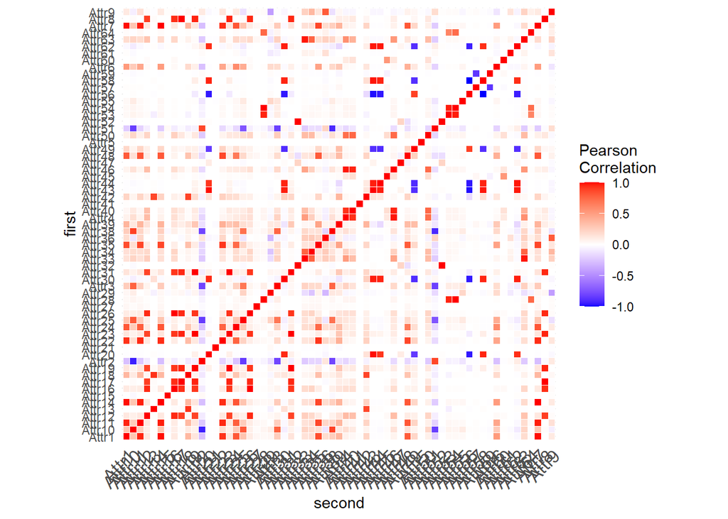

```r
# Remove column "class" to build correlation coefficient matrix
# df_hm has 10503 rows, 63 columns
df_hm <- subset(df1, select= -class)

# Correlation coefficient matrix
corrmatrix <- round(cor(df_hm, use="complete.obs"),2)
corrmatrix <- data.frame(corrmatrix)

# Construct heatmap df using gather
corrmatrix$first <- row.names(corrmatrix)
heatmap <- gather(corrmatrix, "second", "Correlation", 1:63)

# Plot heatmap using ggplot2
ggplot(data = heatmap, aes(second, first, fill = Correlation))+
  geom_tile(color = "white")+
  scale_fill_gradient2(low = "blue", high = "red", mid = "white",
                       midpoint = 0, limit = c(-1,1), space = "Lab",
                       name="Pearson\nCorrelation")+
  theme_minimal()+
  theme(axis.text.x = element_text(angle = 45, vjust = 1,
                                   size = 12, hjust = 1))+
  coord_fixed()
```

Dark red and dark blue dots are highly correlated attrribute pairs. In this project, only one attribute will be retained from each highly correlated group (where correlation < -0.7 or correlation > 0.7) to avoid collinearity issue.

```r
# Check Pearson correlations between attributes
# Filter in all highly correlated attribute pairs.
heatmap %>% filter((Correlation < -0.7 | Correlation > 0.7) & first != second)
```

```
##      first second Correlation
## 1    Attr7  Attr1        0.99
## 2   Attr11  Attr1        0.96
## 3   Attr14  Attr1        0.99
## 4   Attr22  Attr1        0.93
## 5   Attr24  Attr1        0.81
## 6   Attr35  Attr1        0.85
## 7   Attr48  Attr1        0.80
## 8    Attr3  Attr2       -0.80
## 9   Attr10  Attr2       -0.94
## 10  Attr25  Attr2       -0.84
## 11  Attr38  Attr2       -0.80
## 12  Attr51  Attr2        0.87
## 13   Attr2  Attr3       -0.80
## 14  Attr10  Attr3        0.77
```

[output cut: 220 more lines]

The attributes to be retained from all highly correlated groups are:

| Attribute to Retain | Attribute(s) to Remove |
| --- | --- |
| 1 | 7, 11, 14, 22, 24, 35, 48 |
| 2 | 3, 10, 25, 38, 51 |
| 4 | 40, 46, 50 |
| 5 | - |
| 6 | - |
| 8 | 12, 16, 17, 19, 23, 26, 31 |
| 9 | 36 |
| 15 | - |
| 18 | 13, 42 |
| 20 | 30, 43, 44, 49, 56, 58, 62 |
| 21 | - |
| 27 | - |
| 28 | 53, 54, 64 |
| 29 |  |
| 32 | 52 |
| 34 | 33, 63 |
| 39 | - |
| 41 | - |
| 45 | - |
| 47 | - |
| 55 | - |
| 57 | 59 |
| 60 | - |
| 61 | - |

The new heatmap after removal of highly correlated attributes is displayed as below:

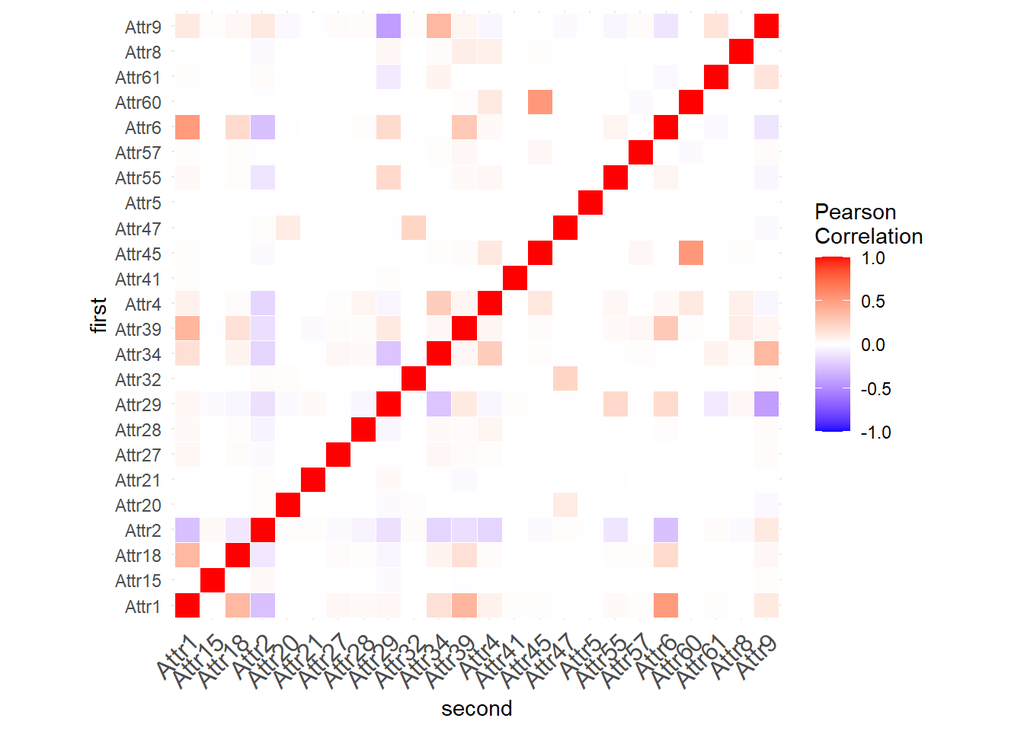

```r
# Retain only attributes in the table above
#df_hm1 has 10503 rows, 24 columns
df_hm1 <- subset(df_hm, select= c("Attr1","Attr2","Attr4","Attr5","Attr6","Attr8",
                                  "Attr9","Attr15","Attr18","Attr20","Attr21",
                                  "Attr27","Attr28","Attr29","Attr32","Attr34",
                                  "Attr39","Attr41","Attr45","Attr47","Attr55",
                                  "Attr57","Attr60","Attr61"))

# Correlation coefficient matrix
corrmatrix1 <- round(cor(df_hm1, use="complete.obs"),2)
corrmatrix1 <- data.frame(corrmatrix1)

# Construct new heatmap1 df using gather
corrmatrix1$first <- row.names(corrmatrix1)
heatmap1 <- gather(corrmatrix1, "second", "Correlation", 1:24)

# Plot new heatmap1 to check all correlations are within -0.7 to 0.7
ggplot(data = heatmap1, aes(second, first, fill = Correlation))+
  geom_tile(color = "white")+
  scale_fill_gradient2(low = "blue", high = "red", mid = "white",
                       midpoint = 0, limit = c(-1,1), space = "Lab",
                       name="Pearson\nCorrelation")+
  theme_minimal()+
  theme(axis.text.x = element_text(angle = 45, vjust = 1,
                                   size = 12, hjust = 1))+
  coord_fixed()
```

```r
# Check Pearson correlations between attributes
# Filter in all the highly correlated attribute pairs.
heatmap1 %>% filter((Correlation < -0.7 | Correlation > 0.7) & first != second)
```

```
## [1] first       second      Correlation
## <0 rows> (or 0-length row.names)
```

No attributes are highly correlated. All correlations are within -0.7 to 0.7.

Retain Attributes 1, 2, 4, 5, 6, 8, 9, 15, 18, 20, 21, 27, 28, 29, 32, 34, 39, 41, 45, 47, 55, 57, 60, 61 and class.

```r
# Retain unique columns and discard other highly correlated columns
df2 <- subset(df1, select= c("Attr1","Attr2","Attr4","Attr5","Attr6","Attr8",
                             "Attr9","Attr15","Attr18","Attr20","Attr21","Attr27",
                             "Attr28","Attr29","Attr32","Attr34","Attr39","Attr41",
                             "Attr45","Attr47","Attr55","Attr57","Attr60","Attr61",
                             "class"))

#Check dimensions of df2
dim(df2)
```

```
## [1] 10503    25
```

df2 has 10503 rows, 25 columns

### 5.4 Exploratory Data Analysis (EDA)

EDA will be performed on all the remaining 24 attributes to further clean and pre-process the dataset. In this section, EDA on Attr1, Attr6, Attr29 and Attr47 will be showcased as examples.

**EDA on Attr1**:

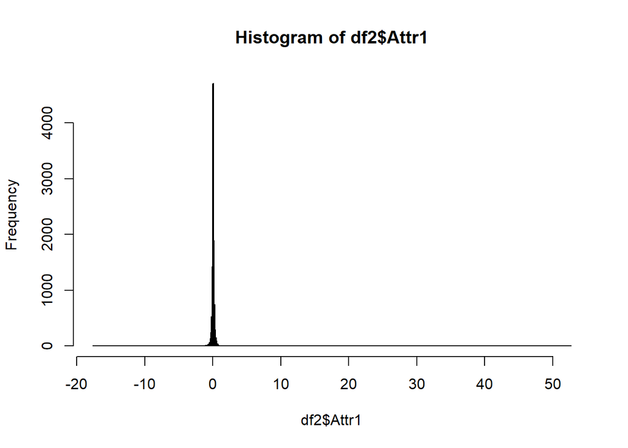

```r
hist(df2$Attr1, breaks=1000)
```

Since most of the data are highly concentrated at one location, the data will be binned into 10 equal-frequency bins.

- Equal-frequency binning of Attr1

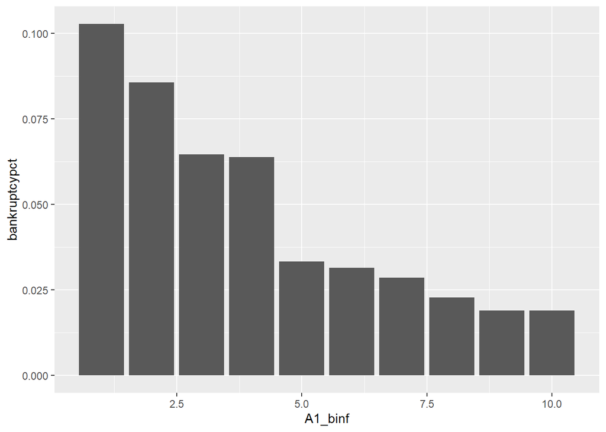

```r
# Add A1_binf column to bin Attr1 into 10 equal-frequency bins
df_A1 <- df2 %>% mutate(A1_binf = ntile(Attr1, n=10))

# Create a new df_A1_binf df
# Select A1_binf and class columns %>%
# Grouped by 10 bins %>%
# Count number of companies in each bin, number of bankruptcies in each bin, and
# add a column as the ratio of bankruptcy to total companies.
df_A1_binf <- df_A1 %>% select(A1_binf,class) %>% group_by(A1_binf) %>%
  summarise(companycnt=n(), bankruptcycnt = sum(ifelse(class=="1",1,0))) %>%
  mutate(bankruptcypct=bankruptcycnt/companycnt)

# Plot bar chart to check the trend between Attr1 bins and bankruptcy ratio
ggplot(data=df_A1_binf, aes(x=A1_binf,y=bankruptcypct)) + geom_bar(stat="identity")
```

Trend can be observed between Attr1 and bankruptcy ratio.

**EDA on Attr6:**

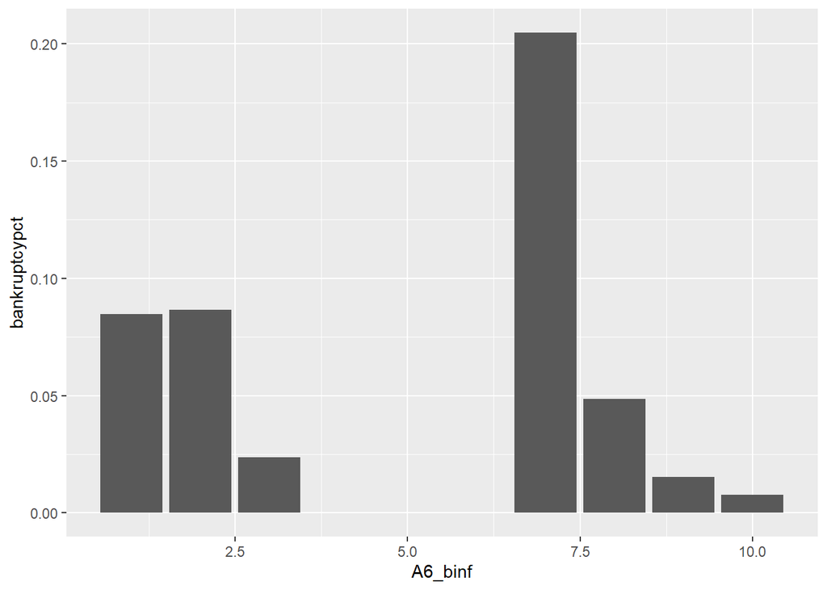

```r
# Add A6_binf column to bin Attr6 into 10 equal-frequency bins
df_A6 <- df2 %>% mutate(A6_binf = ntile(Attr6, n=10))

df_A6_binf <- df_A6 %>% select(A6_binf,class) %>% group_by(A6_binf) %>%
  summarise(companycnt=n(), bankruptcycnt = sum(ifelse(class=="1",1,0))) %>%
  mutate(bankruptcypct=bankruptcycnt/companycnt)

# Plot bar chart to check the trend between Attr6 bins and bankruptcy ratio
ggplot(data=df_A6_binf, aes(x=A6_binf,y=bankruptcypct)) + geom_bar(stat="identity")
```

Trend cannot be observed.

A further scrutiny on Attr6 shows that Attr6 has many zeros (0) in it.

```r
nrow(df_A6[df_A6$Attr6==0,])
```

```
## [1] 4479
```

There are 4479 zeros in Attr6 (42.6% of total rows), which is unlikely for this financial ratio (= retained earnings / total assets). Therefore, Attr6 will be discarded.

**EDA on Attr29:**

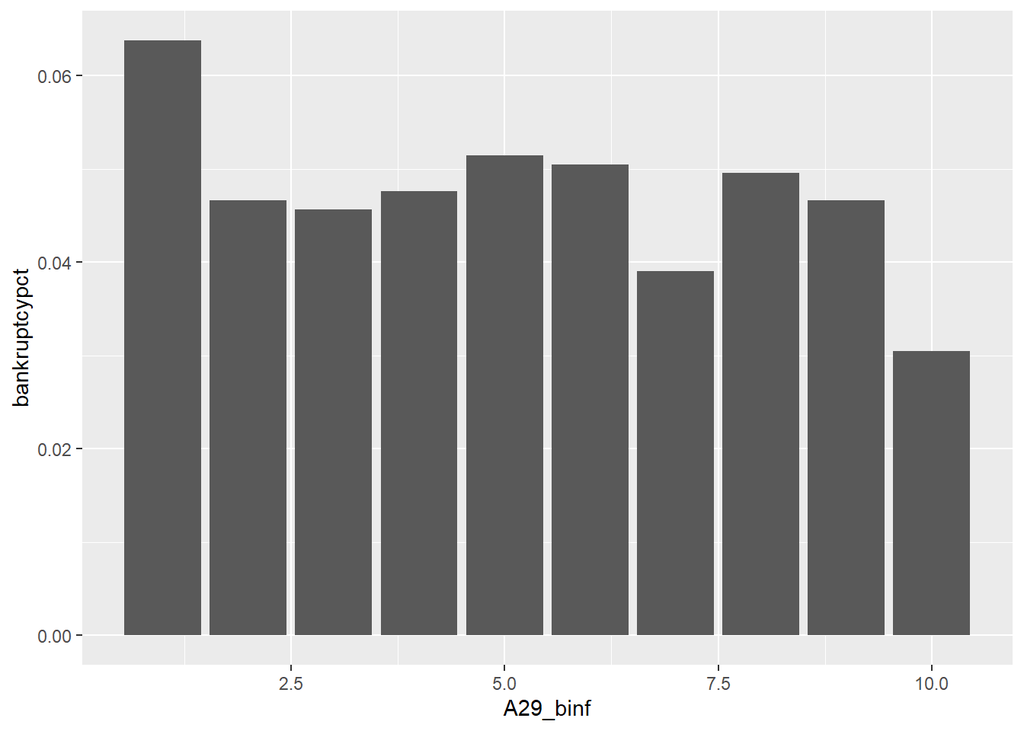

```r
# Add A29_binf column to bin Attr29 into 10 equal-frequency bins
df_A29 <- df2 %>% mutate(A29_binf = ntile(Attr29, n=10))

df_A29_binf <- df_A29 %>% select(A29_binf,class) %>% group_by(A29_binf) %>%
  summarise(companycnt=n(), bankruptcycnt = sum(ifelse(class=="1",1,0))) %>%
  mutate(bankruptcypct=bankruptcycnt/companycnt)

# Plot bar chart to check the trend between Attr29 bins and bankruptcy ratio
ggplot(data=df_A29_binf, aes(x=A29_binf,y=bankruptcypct)) + geom_bar(stat="identity")
```

The trend line is close to flat. Attr29 might be an insignificant attribute to bankruptcy in the modelling later. Attr29 to be retained for now.

**EDA on Attr47:**

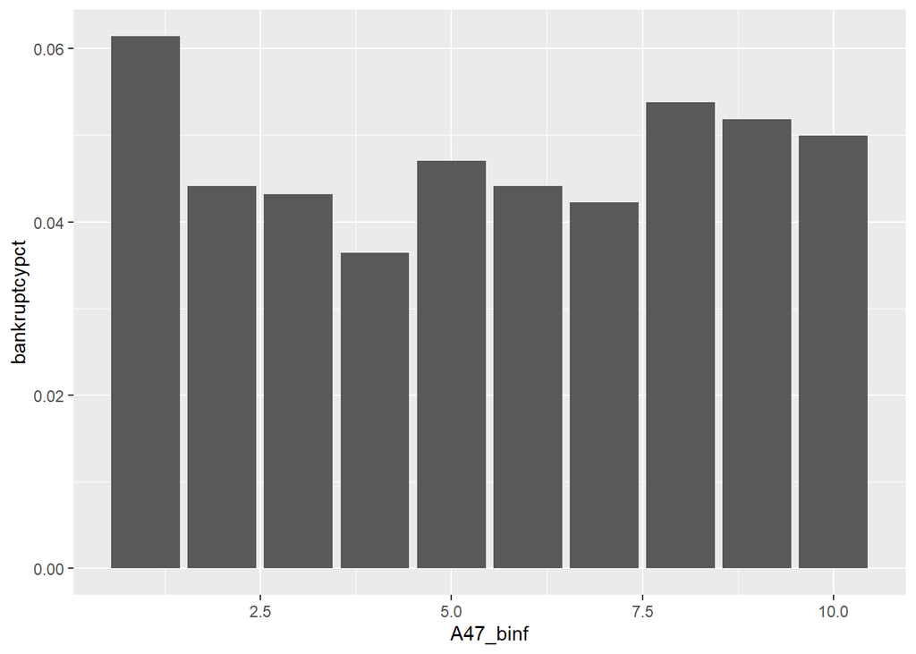

```r
# Add A47_binf column to bin Attr47 into 10 equal-frequency bins
df_A47 <- df2 %>% mutate(A47_binf = ntile(Attr47, n=10))

df_A47_binf <- df_A47 %>% select(A47_binf,class) %>% group_by(A47_binf) %>%
  summarise(companycnt=n(), bankruptcycnt = sum(ifelse(class=="1",1,0))) %>%
  mutate(bankruptcypct=bankruptcycnt/companycnt)

# Plot bar chart to check the trend between Attr47 bins and bankruptcy ratio
ggplot(data=df_A47_binf, aes(x=A47_binf,y=bankruptcypct)) + geom_bar(stat="identity")
```

The trend line is close to flat. Attr47 might be an insignificant attribute to bankruptcy in the modelling later. Attr47 to be retained for now.

**Removing Attr6**

```r
# Remove Attr6 column
df3 <- subset(df2, select= -Attr6)

# Check dimensions of df3
dim(df3)
```

```
## [1] 10503    24
```

df3 has 10503 rows, 24 columns

### 5.5 Imputation for Columns with Percentage of NA’s 1% to 10%

**Imputing zeros (0) to Attr21’s NA rows**

```r
df4 <- df3

# Impute 0 to Attr21's NA rows
df4[is.na(df4$Attr21),10] <- 0
```

**Imputing medians to Attr27, Attr28, Attr41, Attr45 and Attr60’s NA rows**

As Attr27, Attr28, Attr41, Attr45 and Attr60’s data are **skewed**, imputing medians to the NA rows is a better choice than means.

```r
# Impute medians to Attr27 NA rows
df4[is.na(df4$Attr27),11] <- median(df4$Attr27, na.rm=TRUE)

# Impute medians to Attr28 NA rows
df4[is.na(df4$Attr28),12] <- median(df4$Attr28, na.rm=TRUE)

# Impute medians to Attr41 NA rows
df4[is.na(df4$Attr41),17] <- median(df4$Attr41, na.rm=TRUE)

# Impute medians to Attr45 NA rows
df4[is.na(df4$Attr45),18] <- median(df4$Attr45, na.rm=TRUE)

# Impute medians to Attr60 NA rows
df4[is.na(df4$Attr60),22] <- median(df4$Attr60, na.rm=TRUE)
```

### 5.6 Removing Rows for Columns with Percentage of NA’s < 1%

There are still some NA’s for Attr4 (0.17%), Attr5 (0.24%), Attr8 (0.13%), Attr9 (0.03%), Attr15 (0.08%), Attr20 (0.41%), Attr32 (0.96%), Attr34 (0.13%), Attr39 (0.41%), Attr47 (0.82%) and Attr61 (0.16%).

```r
# Check number of NA rows to be deleted
nrow(df4[is.na(df4$Attr4) | is.na(df4$Attr5) | is.na(df4$Attr8) | is.na(df4$Attr9) |
    is.na(df4$Attr15) | is.na(df4$Attr20) | is.na(df4$Attr32) | is.na(df4$Attr34) |
    is.na(df4$Attr39) | is.na(df4$Attr47) | is.na(df4$Attr61),])
```

```
## [1] 168
```

Total number of rows to be deleted is 168, which is 1.6% of total rows (10503 rows).

Removing NA rows:

```r
# Delete 168 NA rows
df5 <- df4[!(is.na(df4$Attr4) | is.na(df4$Attr5) | is.na(df4$Attr8) | is.na(df4$Attr9) |
          is.na(df4$Attr15) | is.na(df4$Attr20) | is.na(df4$Attr32) | is.na(df4$Attr34) |
          is.na(df4$Attr39) | is.na(df4$Attr47) | is.na(df4$Attr61)),]
```

```r
# Check dimensions of df5
dim(df5)
```

```
## [1] 10335    24
```

df5 contains 10335 rows, 24 columns.

## 6. Tidy Dataset, Z-Score Normalisation, Data Partition & SMOTE

### 6.1 Tidy Dataset

In order to suit the library requirements in the Modelling section, labels for “class” column have to be renamed as “Sustain” and “Bankrupt”.

```r
# Change class labels from "0" & "1" to "Sustain" & "Bankrupt"
df5$class = as.factor(df5$class)
levels(df5$class) <- c("Sustain","Bankrupt")
```

There is no NA in the tidy dataset df5 anymore.

```r
# Check whether there is NA in tidy dataset
any(is.na(df5))
```

```
## [1] FALSE
```

The tidy dataset is df5 and it contains 10335 rows and 24 columns (23 attributes + 1 class columns).

```r
# Check number of rows
#nrow(df5) # 10335 total rows
#nrow(df5[df5$class=="Sustain",]) # 9847 Sustain rows
#nrow(df5[df5$class=="Bankrupt",]) # 488 Bankrupt rows

# Save tidy dataset df5
write.csv(df5, file="df5.csv", row.names=FALSE)
```

### 6.2 Data Transformation with Z-Score Normalisation

```r
# Load all the required packages
library(caret)
library(performanceEstimation) # For SMOTE
library(randomForest) # For Random Forest
library(MLeval) # For evalm
library(fastAdaboost) # For AdaBoost
```

As the data within the attributes are highly concentrated at a narrow range (spike), the data will be spread out by Z-score normalisation such that it has a lower peak and less outliers.

```r
# Z-score normalisation
# df5 has 24 columns (23 Attr + 1 class)
# 23 Attr columns to be Z-score normalised
tot_attr_col <- ncol(df5)-1
preproc <- preProcess(df5[,c(1:tot_attr_col)], method=c("center","scale"))
z_df5 <- predict(preproc, df5)

summary(z_df5)
```

```
##      Attr1               Attr2              Attr4              Attr5
##  Min.   :-44.91985   Min.   :-0.09569   Min.   :-0.11072   Min.   :-99.68770
##  1st Qu.: -0.12222   1st Qu.:-0.05613   1st Qu.:-0.08452   1st Qu.:  0.01099
##  Median : -0.01423   Median :-0.02385   Median :-0.07029   Median :  0.01143
##  Mean   :  0.00000   Mean   : 0.00000   Mean   : 0.00000   Mean   :  0.00000
##  3rd Qu.:  0.19015   3rd Qu.: 0.01069   3rd Qu.:-0.03659   3rd Qu.:  0.01189
##  Max.   : 51.73199   Max.   :74.12415   Max.   :79.94393   Max.   :  5.75264
##      Attr8              Attr9              Attr15              Attr18
##  Min.   :-0.03051   Min.   :-0.23881   Min.   :-21.14835   Min.   :-26.81172
##  1st Qu.:-0.02455   1st Qu.:-0.10612   1st Qu.: -0.02646   1st Qu.: -0.09791
##  Median :-0.02295   Median :-0.08156   Median : -0.02084   Median : -0.02375
##  Mean   : 0.00000   Mean   : 0.00000   Mean   :  0.00000   Mean   :  0.00000
##  3rd Qu.:-0.01887   3rd Qu.: 0.03088   3rd Qu.: -0.00825   3rd Qu.:  0.11400
##  Max.   :70.17533   Max.   :96.73897   Max.   : 93.08279   Max.   : 80.95381
##      Attr20             Attr21              Attr27             Attr28
##  Min.   :-0.06678   Min.   : -0.01849   Min.   :-5.66494   Min.   :-7.43299
##  1st Qu.:-0.05150   1st Qu.: -0.01223   1st Qu.:-0.03330   1st Qu.:-0.06151
##  Median :-0.03027   Median : -0.01160   Median :-0.03327   Median :-0.05698
##  Mean   : 0.00000   Mean   :  0.00000   Mean   : 0.00000   Mean   : 0.00000
##  3rd Qu.: 0.00069   3rd Qu.: -0.01108   3rd Qu.:-0.03318   3rd Qu.:-0.04591
##  Max.   :97.12529   Max.   :100.92315   Max.   :80.62175   Max.   :66.48830
##      Attr29              Attr32             Attr34             Attr39
##  Min.   :-5.187541   Min.   :-0.02269   Min.   :-0.82339   Min.   :-67.79603
##  1st Qu.:-0.636035   1st Qu.:-0.01626   1st Qu.:-0.17851   1st Qu.:  0.00966
##  Median : 0.008781   Median :-0.01578   Median :-0.11196   Median :  0.01371
##  Mean   : 0.000000   Mean   : 0.00000   Mean   : 0.00000   Mean   :  0.00000
##  3rd Qu.: 0.631878   3rd Qu.:-0.01503   3rd Qu.:-0.00481   3rd Qu.:  0.02070
##  Max.   : 4.404158   Max.   :97.23331   Max.   :76.99917   Max.   : 36.07698
##      Attr41              Attr45              Attr47
##  Min.   : -0.24514   Min.   :-44.16609   Min.   : -0.01588
##  1st Qu.: -0.01007   1st Qu.: -0.00973   1st Qu.: -0.01485
##  Median : -0.01005   Median : -0.00959   Median : -0.01365
##  Mean   :  0.00000   Mean   :  0.00000   Mean   :  0.00000
##  3rd Qu.: -0.01001   3rd Qu.: -0.00921   3rd Qu.: -0.01187
##  Max.   :101.64781   Max.   : 67.23542   Max.   :100.93294
##      Attr55              Attr57              Attr60              Attr61
##  Min.   :-12.78617   Min.   :-88.63462   Min.   : -0.01506   Min.   :-0.25115
##  1st Qu.: -0.10896   1st Qu.:  0.00171   1st Qu.: -0.01490   1st Qu.:-0.11399
##  Median : -0.09411   Median :  0.00707   Median : -0.01478   Median :-0.08703
##  Mean   :  0.00000   Mean   :  0.00000   Mean   :  0.00000   Mean   : 0.00000
##  3rd Qu.: -0.03546   3rd Qu.:  0.01578   3rd Qu.: -0.01451   3rd Qu.:-0.03851
##  Max.   : 56.92500   Max.   : 29.38041   Max.   :100.56881   Max.   :55.00736
##       class
##  Sustain :9847
##  Bankrupt: 488
##
##
##
##
```

```r
# Save tidy dataset z_df5
write.csv(z_df5, file="z_df5.csv", row.names=FALSE)
```

Before Z-score normalisation, Attr61 has a higher peak (frequency up to 4000) and more outliers (x-axis up to 4000).

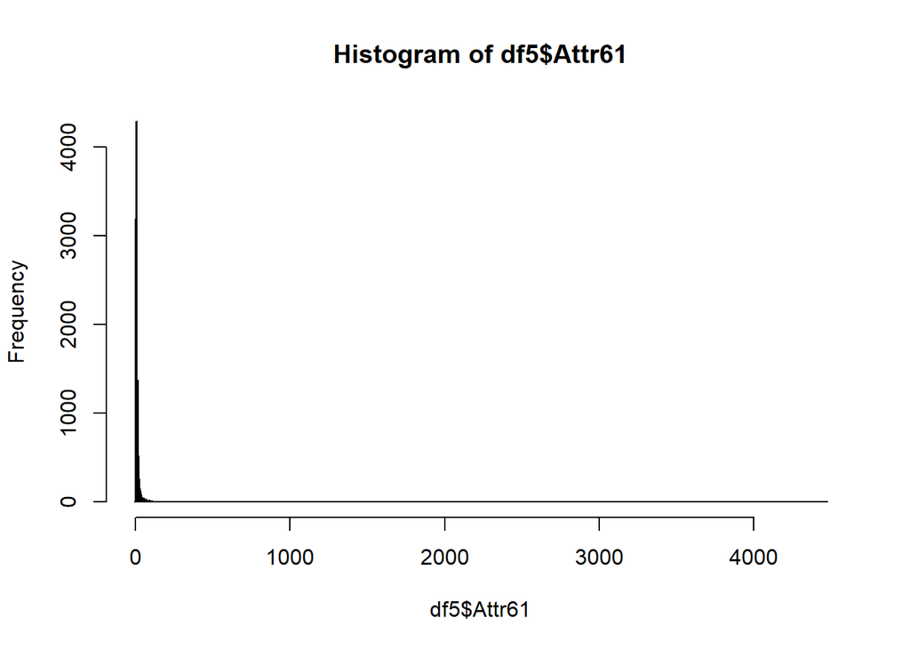

```r
hist(df5$Attr61, breaks=1000)
```

After Z-score normalisation, Attr61 has a lower peak (frequency up to 3000) and less outliers (x-axis up to 50).

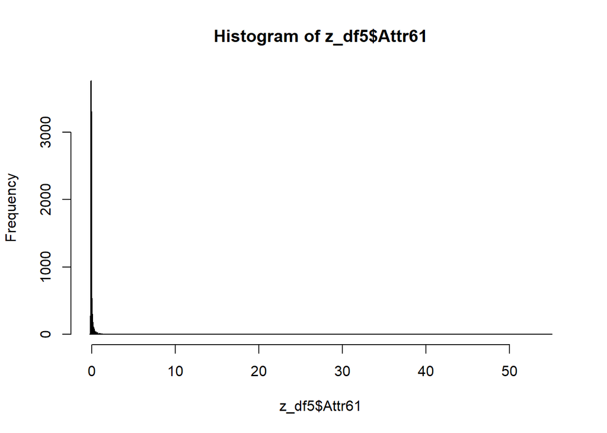

```r
hist(z_df5$Attr61, breaks=1000)
```

### 6.3 Data Partition

Dataset, df5 and normalised dataset, z_df5 are partitioned into **training set** (80% of rows) and **testing set** (20% of rows) for modelling in **Section 7**.

```r
# Write data partition function
split_traintest <- function(dataframe){
  set.seed(7) # Set seed as 7 for reproducibility
  split=0.80  # Define an 80%/20% train/test split
  trainIndex <- createDataPartition(dataframe$class, p=split, list=FALSE)
  data_train <- dataframe[trainIndex,]
  data_test <- dataframe[-trainIndex,]
  return(list(data_train,data_test))
}
```

```r
# Data Partition for dataset df5
data_set <-split_traintest(df5)
train_set <- data_set[[1]]
test_set <- data_set[[2]]

# Check number of rows
#nrow(train_set) # 8269 total rows
#nrow(train_set[train_set$class=="Sustain",]) # 7878 Sustain rows
#nrow(train_set[train_set$class=="Bankrupt",]) # 391 Bankrupt rows

# Save training set
write.csv(train_set, file="train_set.csv", row.names=FALSE)

# Save testing set
write.csv(test_set, file="test_set.csv", row.names=FALSE)
```

```r
# Data Partition for normalised dataset z_df5
z_data_set <-split_traintest(z_df5)
z_train_set <- z_data_set[[1]]
z_test_set <- z_data_set[[2]]

# Check number of rows
#nrow(z_train_set) # 8269 total rows
#nrow(z_train_set[z_train_set$class=="Sustain",]) # 7878 Sustain rows
#nrow(z_train_set[z_train_set$class=="Bankrupt",]) # 391 Bankrupt rows

# Save training set
write.csv(z_train_set, file="z_train_set.csv", row.names=FALSE)

# Save testing set
write.csv(z_test_set, file="z_test_set.csv", row.names=FALSE)
```

### 6.4 Oversampling & Undersampling with SMOTE

As our data are imbalanced, i.e. 95% “Sustain” vs. 5% “Bankrupt”, Synthetic Minority Oversampling TEchnique (SMOTE) is adopted to oversample the minority class and undersample the majority class such that the dataset is more balanced (52% “Sustain” vs. 48% “Bankrupt”). SMOTE will only be applied on the training sets (train_set & z_train_set) but not on the testing sets (test_set & z_test_set).

```r
# Write SMOTE function
# Set k-nearest neighbours to generate the new bankrupt samples = 5
# Set perc.over = 10 (new additional bankrupt samples = 10 times of original bankrupt samples)
# Set perc.under = 1.2 (Sustain samples = 1.2x10 times of original bankrupt samples)

smote_training_func <- function(dataframe){
  set.seed(1234) # Set seed as 1234 for reproducibility
  return(smote(dataframe$class~., dataframe, perc.over = 10, k = 5, perc.under = 1.2))
}
```

```r
# To SMOTE train_set
smote_train_set <- smote_training_func(train_set)

#nrow(smote_train_set) # 8993 rows = 4692 + 4301 (52% vs. 48%)
#nrow(smote_train_set[smote_train_set$class=="Sustain",]) # 4692 rows = 1.2(10)(391)
#nrow(smote_train_set[smote_train_set$class=="Bankrupt",]) # 4301 rows = 391 + 10(391)

# Save training set
write.csv(smote_train_set, file="smote_train_set.csv", row.names=FALSE)
```

```r
# To SMOTE z_train_set
smote_z_train_set <- smote_training_func(z_train_set)

#nrow(smote_z_train_set) # 8993 rows = 4692 + 4301 (52% vs. 48%)
#nrow(smote_z_train_set[smote_z_train_set$class=="Sustain",]) # 4692 rows = 1.2(10)(391)
#nrow(smote_z_train_set[smote_z_train_set$class=="Bankrupt",]) # 4301 rows = 391 + 10(391)

# Save training set
write.csv(smote_z_train_set, file="smote_z_train_set.csv", row.names=FALSE)
```

## 7. Modelling

Models of different machine learning types (classification and regression), methods (Random Forest, k-Nearest Neighbours, Adaboost and Logistic Regression), and treatments (z-score normalisation, SMOTE, 10-fold cross validation) will be studied and compared in this project.

To address the overfitting issue during the training phase of the machine learning, **10-fold cross validation** is employed in all the models.

The details of these 12 models are displayed as follows:

**Table 7.1**: Details of 12 machine learning models

| Model | Machine Learning Type | Machine Learning Method | Z-Score Normalisation | SMOTE | 10-Fold Cross Validation |
| --- | --- | --- | --- | --- | --- |
| 1A | Classification | Random Forest | Yes | Yes | Yes |
| 1B | Classification | Random Forest | - | Yes | Yes |
| 1C | Classification | Random Forest | Yes | - | Yes |
| 2A | Classification | k-Nearest Neighbours | Yes | Yes | Yes |
| 2B | Classification | k-Nearest Neighbours | - | Yes | Yes |
| 2C | Classification | k-Nearest Neighbours | Yes | - | Yes |
| 3A | Classification | AdaBoost | Yes | Yes | Yes |
| 3B | Classification | AdaBoost | - | Yes | Yes |
| 3C | Classification | AdaBoost | Yes | - | Yes |
| 4A | Regression | Logistic Regression | Yes | Yes | Yes |
| 4B | Regression | Logistic Regression | - | Yes | Yes |
| 4C | Regression | Logistic Regression | Yes | - | Yes |

### 7.1 Random Forest Classification Analysis

#### Model 1A: Random Forest with Normalisation, SMOTE & Cross Validation

```r
# Model 1A
# 10-fold cross validation
train_control <- trainControl(method="repeatedcv", number=10, repeats=1, classProbs=TRUE)
#rf_cv_smote_z <- train(class~., data=smote_z_train_set, trControl=train_control, method="rf")
#saveRDS(rf_cv_smote_z, "rf_cv_smote_z.rds")
rf_cv_smote_z <- readRDS("rf_cv_smote_z.rds")
rf_cv_smote_z
```

```
## Random Forest
##
## 8993 samples
##   23 predictor
##    2 classes: 'Sustain', 'Bankrupt'
##
## No pre-processing
## Resampling: Cross-Validated (10 fold, repeated 1 times)
## Summary of sample sizes: 8094, 8094, 8094, 8094, 8093, 8093, ...
## Resampling results across tuning parameters:
##
##   mtry  Accuracy   Kappa
##    2    0.9584119  0.9167675
##   12    0.9585233  0.9169896
##   23    0.9552992  0.9105427
##
## Accuracy was used to select the optimal model using the largest value.
## The final value used for the model was mtry = 12.
```

```r
# Predict Sustain or Bankrupt for z_test_set
pred1a <- predict(rf_cv_smote_z, newdata=z_test_set, type="prob")
test1a <- evalm(data.frame(pred1a, z_test_set$class)) #AUC-ROC = 0.83
```

```
## ***MLeval: Machine Learning Model Evaluation***
```

```
## Input: data frame of probabilities of observed labels
```

```
## Group does not exist, making column.
```

```
## Observations: 2066
```

```
## Number of groups: 1
```

```
## Observations per group: 2066
```

```
## Positive: Bankrupt
```

```
## Negative: Sustain
```

```
## Group: Group1
```

```
## Positive: 97
```

```
## Negative: 1969
```

```
## ***Performance Metrics***
```

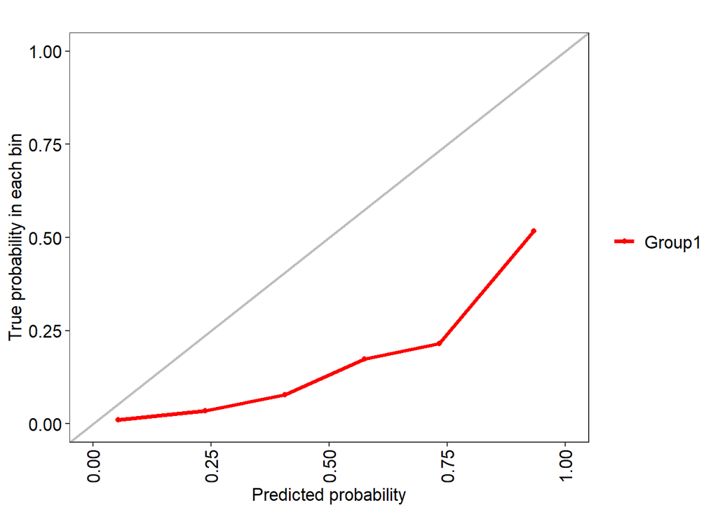

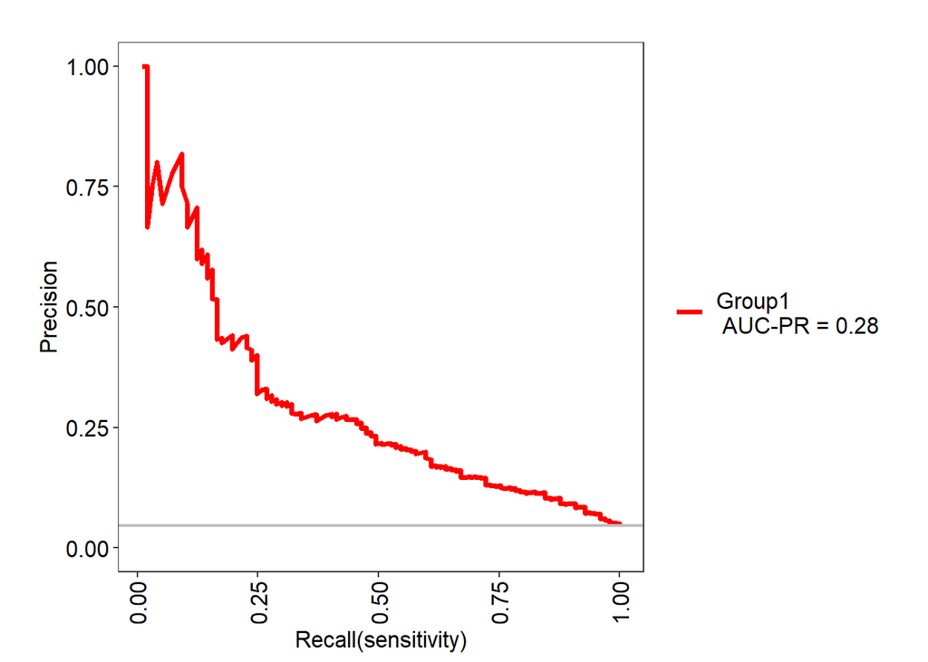

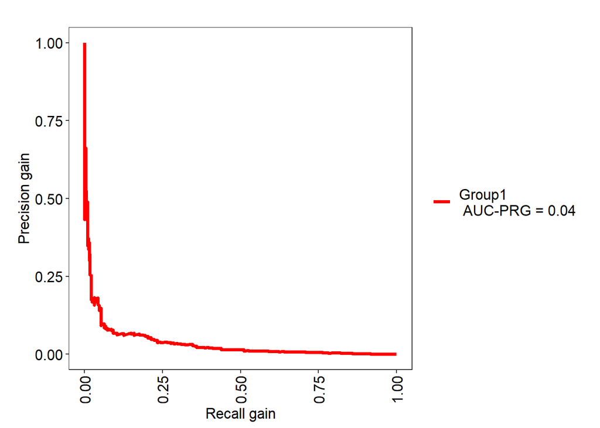

```
## Group1 Optimal Informedness = 0.524385710471064
```

```
## Group1 AUC-ROC = 0.83
```

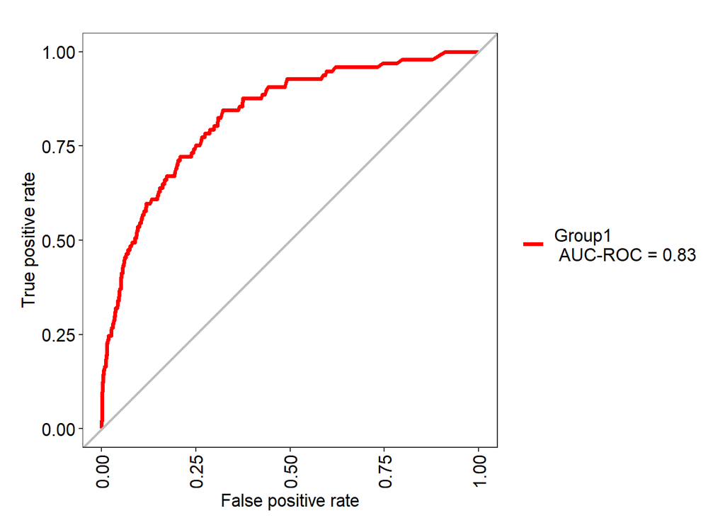

#### Model 1B: Random Forest with SMOTE & Cross Validation

```r
# Model 1B
# 10-fold cross validation
train_control <- trainControl(method="repeatedcv", number=10, repeats=1, classProbs=TRUE)
#rf_cv_smote <- train(class~., data=smote_train_set, trControl=train_control, method="rf")
#saveRDS(rf_cv_smote, "rf_cv_smote.rds")
rf_cv_smote <- readRDS("rf_cv_smote.rds")
rf_cv_smote
```

```
## Random Forest
##
## 8993 samples
##   23 predictor
##    2 classes: 'Sustain', 'Bankrupt'
##
## No pre-processing
## Resampling: Cross-Validated (10 fold, repeated 1 times)
## Summary of sample sizes: 8094, 8094, 8094, 8093, 8094, 8094, ...
## Resampling results across tuning parameters:
##
##   mtry  Accuracy   Kappa
##    2    0.9583011  0.9165208
##   12    0.9586354  0.9172087
##   23    0.9561892  0.9123203
##
## Accuracy was used to select the optimal model using the largest value.
## The final value used for the model was mtry = 12.
```

```r
# Predict Sustain or Bankrupt for test_set
pred1b <- predict(rf_cv_smote, newdata=test_set, type="prob")
test1b <- evalm(data.frame(pred1b, test_set$class)) #AUC-ROC = 0.83
```

```
## ***MLeval: Machine Learning Model Evaluation***
```

```
## Input: data frame of probabilities of observed labels
```

```
## Group does not exist, making column.
```

```
## Observations: 2066
```

```
## Number of groups: 1
```

```
## Observations per group: 2066
```

```
## Positive: Bankrupt
```

```
## Negative: Sustain
```

```
## Group: Group1
```

```
## Positive: 97
```

```
## Negative: 1969
```

```
## ***Performance Metrics***
```

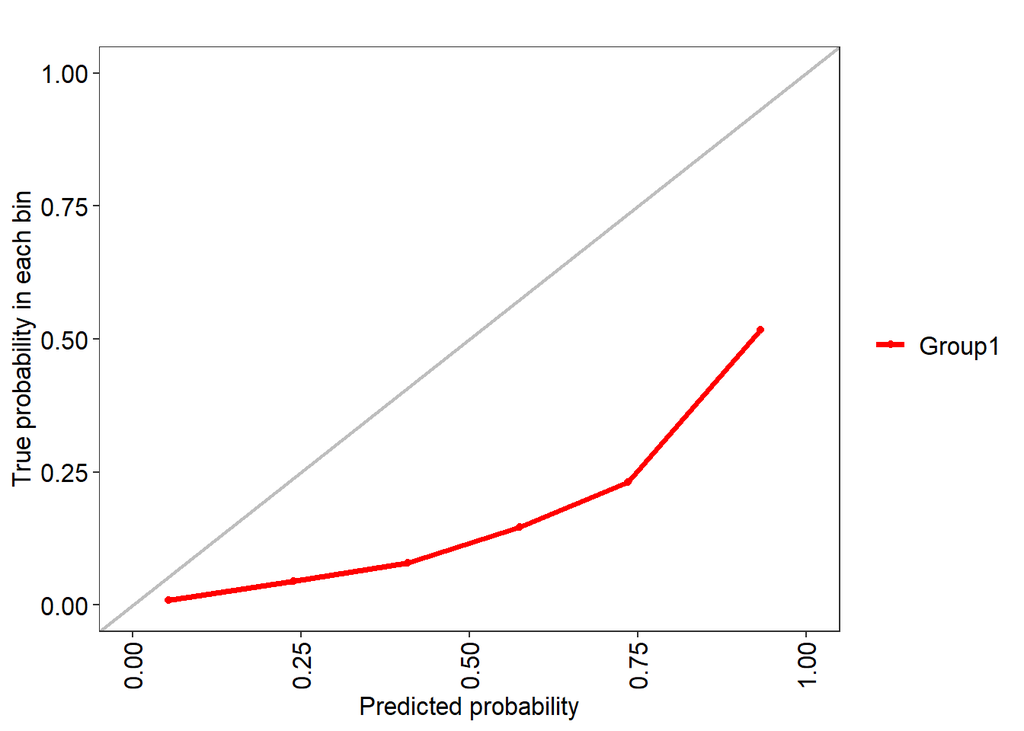

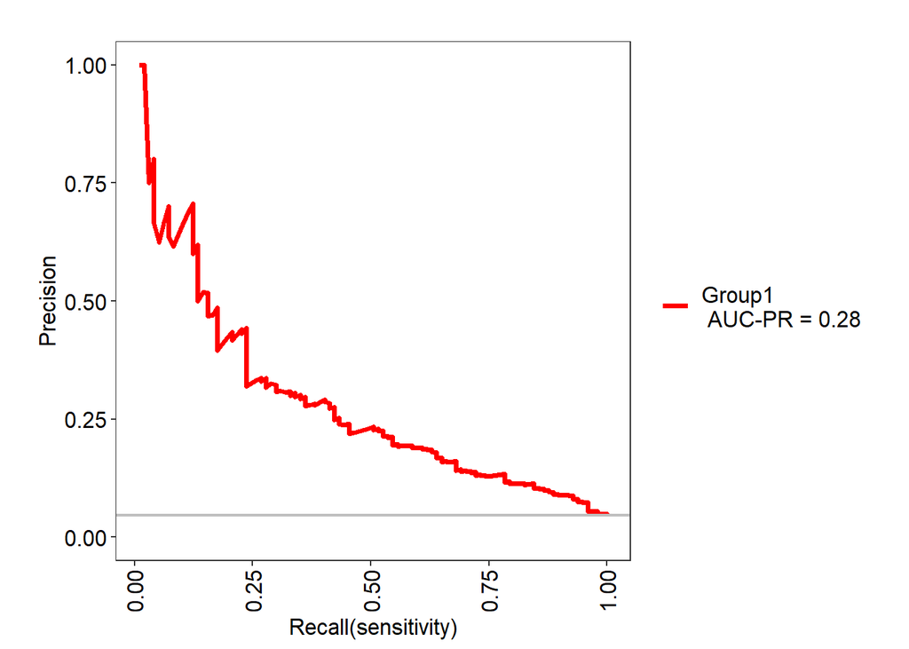

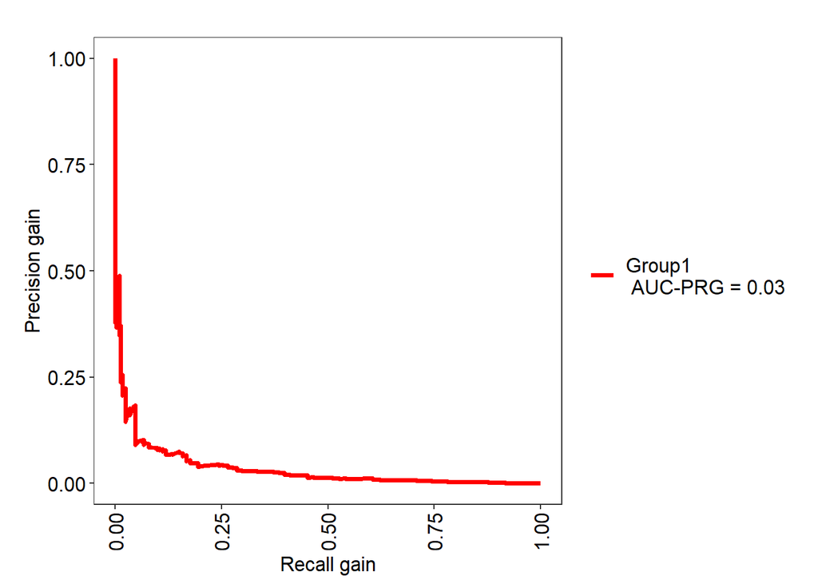

```
## Group1 Optimal Informedness = 0.533124250626986
```

```
## Group1 AUC-ROC = 0.83
```

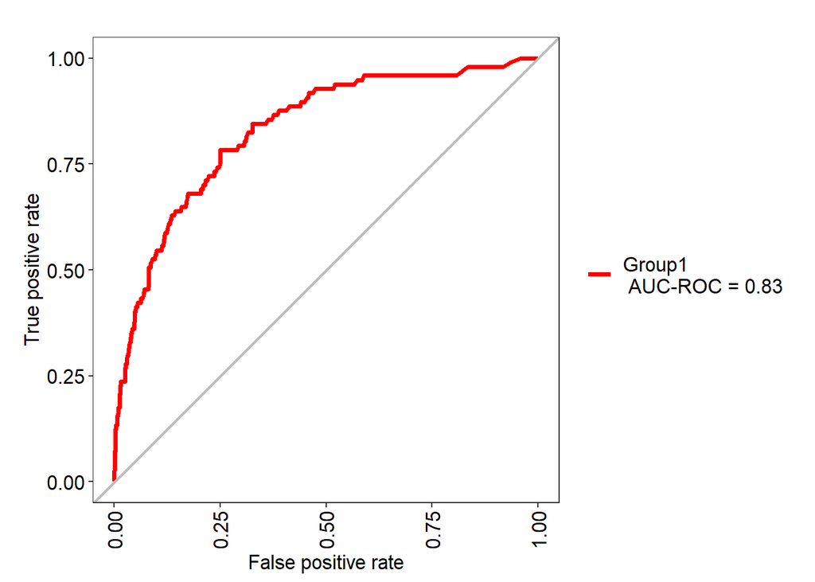

#### Model 1C: Random Forest with Normalisation & Cross Validation

```r
# Model 1C
# 10-fold cross validation
train_control <- trainControl(method="repeatedcv", number=10, repeats=1, classProbs=TRUE)
#rf_cv_z <- train(class~., data=z_train_set, trControl=train_control, method="rf")
#saveRDS(rf_cv_z, "rf_cv_z.rds")
rf_cv_z <- readRDS("rf_cv_z.rds")
rf_cv_z
```

```
## Random Forest
##
## 8269 samples
##   23 predictor
##    2 classes: 'Sustain', 'Bankrupt'
##
## No pre-processing
## Resampling: Cross-Validated (10 fold, repeated 1 times)
## Summary of sample sizes: 7442, 7442, 7442, 7442, 7442, 7443, ...
## Resampling results across tuning parameters:
##
##   mtry  Accuracy   Kappa
##    2    0.9518678  0.07725012
##   12    0.9593661  0.33353591
##   23    0.9590035  0.33557928
##
## Accuracy was used to select the optimal model using the largest value.
## The final value used for the model was mtry = 12.
```

```r
# Predict Sustain or Bankrupt for z_test_set
pred1c <- predict(rf_cv_z, newdata=z_test_set, type="prob")
test1c <- evalm(data.frame(pred1c, z_test_set$class)) #AUC-ROC = 0.83
```

```
## ***MLeval: Machine Learning Model Evaluation***
```

```
## Input: data frame of probabilities of observed labels
```

```
## Group does not exist, making column.
```

```
## Observations: 2066
```

```
## Number of groups: 1
```

```
## Observations per group: 2066
```

```
## Positive: Bankrupt
```

```
## Negative: Sustain
```

```
## Group: Group1
```

```
## Positive: 97
```

```
## Negative: 1969
```

```
## ***Performance Metrics***
```

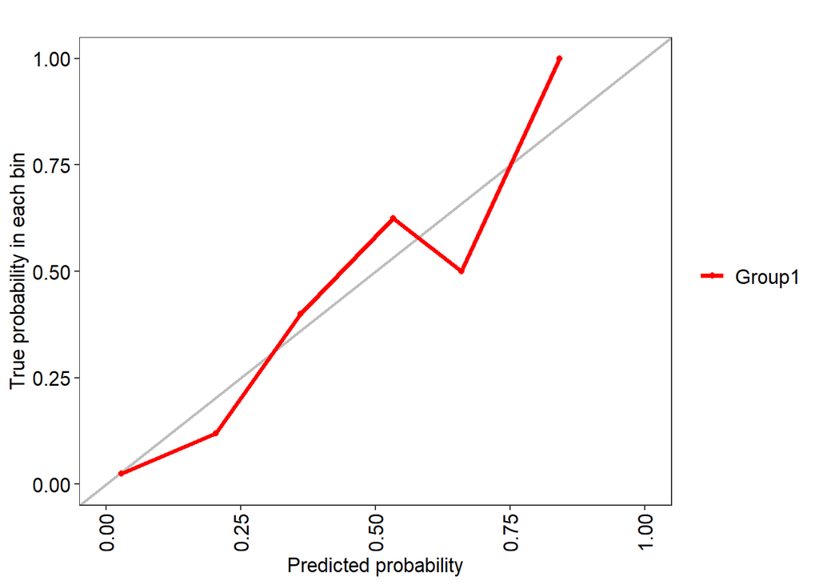

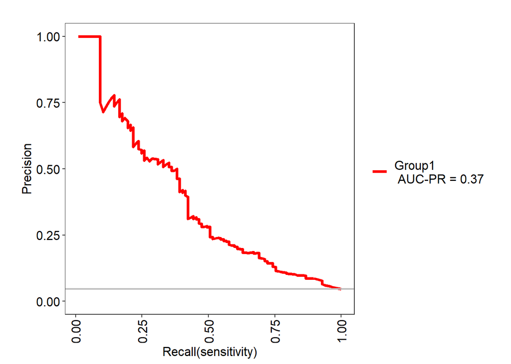

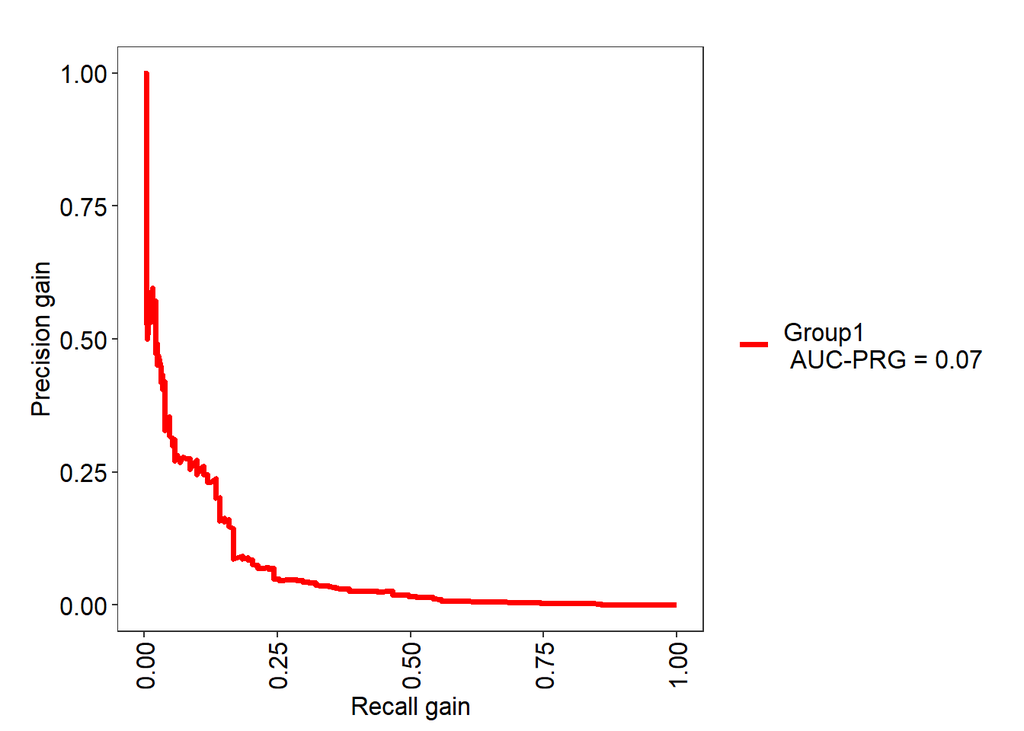

```
## Group1 Optimal Informedness = 0.537852172592713
```

```
## Group1 AUC-ROC = 0.83
```

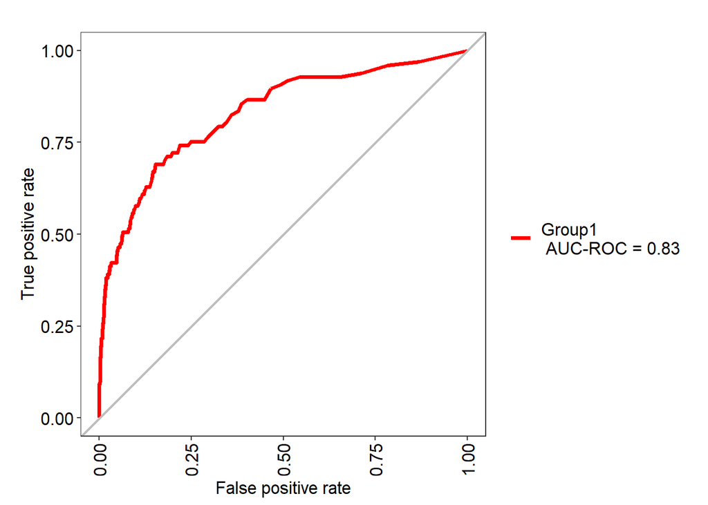

### 7.2 k-Nearest Neighbours Classification Analysis

#### Model 2A: kNN with Normalisation, SMOTE & Cross Validation

```r
# Model 2A
# 10-fold cross validation
train_control <- trainControl(method="repeatedcv", number=10, repeats=1, classProbs=TRUE)
#knn_cv_smote_z <- train(class~., data=smote_z_train_set, trControl=train_control, method="knn")
#saveRDS(knn_cv_smote_z, "knn_cv_smote_z.rds")
knn_cv_smote_z <- readRDS("knn_cv_smote_z.rds")
knn_cv_smote_z
```

```
## k-Nearest Neighbors
##
## 8993 samples
##   23 predictor
##    2 classes: 'Sustain', 'Bankrupt'
##
## No pre-processing
## Resampling: Cross-Validated (10 fold, repeated 1 times)
## Summary of sample sizes: 8094, 8094, 8094, 8094, 8094, 8094, ...
## Resampling results across tuning parameters:
##
##   k  Accuracy   Kappa
##   5  0.8186358  0.6396271
##   7  0.8117436  0.6261915
##   9  0.8034057  0.6095379
##
## Accuracy was used to select the optimal model using the largest value.
## The final value used for the model was k = 5.
```

```r
# Predict Sustain or Bankrupt for z_test_set
pred2a <- predict(knn_cv_smote_z, newdata=z_test_set, type="prob")
test2a <- evalm(data.frame(pred2a, z_test_set$class)) #AUC-ROC = 0.6
```

```
## ***MLeval: Machine Learning Model Evaluation***
```

```
## Input: data frame of probabilities of observed labels
```

```
## Group does not exist, making column.
```

```
## Observations: 2066
```

```
## Number of groups: 1
```

```
## Observations per group: 2066
```

```
## Positive: Bankrupt
```

```
## Negative: Sustain
```

```
## Group: Group1
```

```
## Positive: 97
```

```
## Negative: 1969
```

```
## ***Performance Metrics***
```

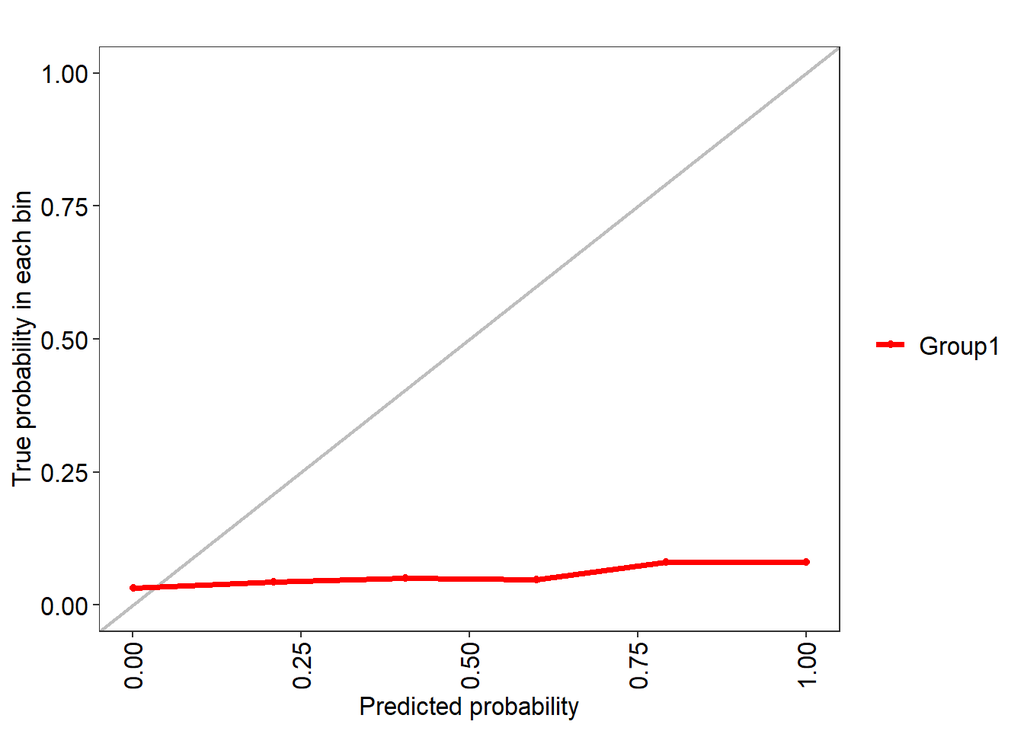

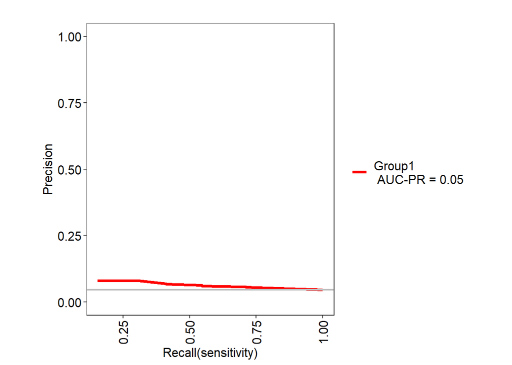

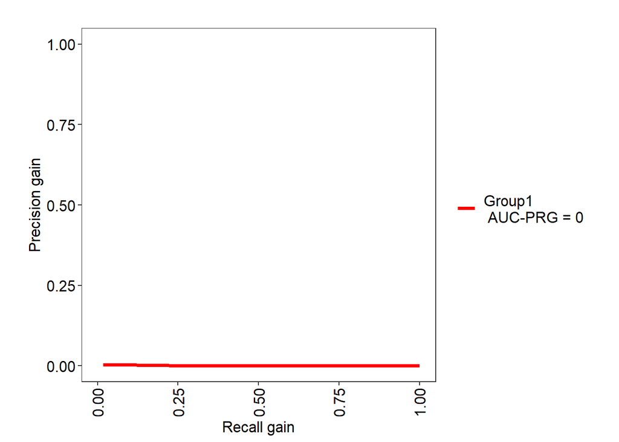

```
## Group1 Optimal Informedness = 0.150251579900834
```

```
## Group1 AUC-ROC = 0.6
```

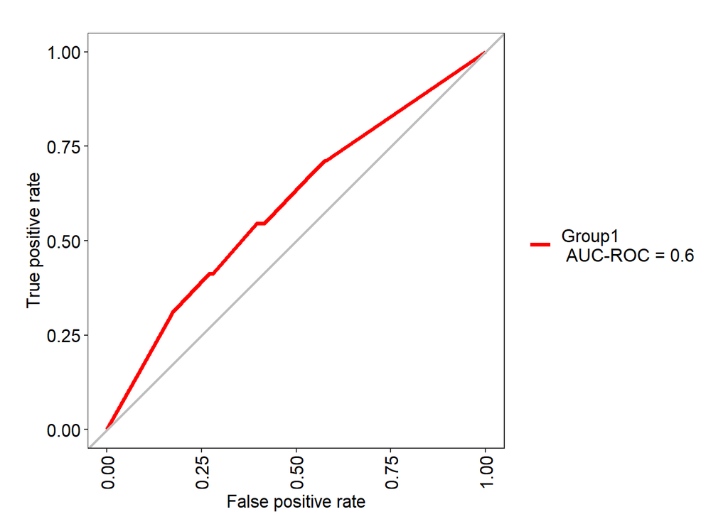

#### Model 2B: kNN with SMOTE & Cross Validation

```r
# Model 2B
# 10-fold cross validation
train_control <- trainControl(method="repeatedcv", number=10, repeats=1, classProbs=TRUE)
#knn_cv_smote <- train(class~., data=smote_train_set, trControl=train_control, method="knn")
#saveRDS(knn_cv_smote, "knn_cv_smote.rds")
knn_cv_smote <- readRDS("knn_cv_smote.rds")
knn_cv_smote
```

```
## k-Nearest Neighbors
##
## 8993 samples
##   23 predictor
##    2 classes: 'Sustain', 'Bankrupt'
##
## No pre-processing
## Resampling: Cross-Validated (10 fold, repeated 1 times)
## Summary of sample sizes: 8094, 8093, 8094, 8094, 8094, 8093, ...
## Resampling results across tuning parameters:
##
##   k  Accuracy   Kappa
##   5  0.7306817  0.4607085
##   7  0.7273436  0.4542475
##   9  0.7198935  0.4398227
##
## Accuracy was used to select the optimal model using the largest value.
## The final value used for the model was k = 5.
```

```r
# Predict Sustain or Bankrupt for test_set
pred2b <- predict(knn_cv_smote, newdata=test_set, type="prob")
test2b <- evalm(data.frame(pred2b, test_set$class)) #AUC-ROC = 0.62
```

```
## ***MLeval: Machine Learning Model Evaluation***
```

```
## Input: data frame of probabilities of observed labels
```

```
## Group does not exist, making column.
```

```
## Observations: 2066
```

```
## Number of groups: 1
```

```
## Observations per group: 2066
```

```
## Positive: Bankrupt
```

```
## Negative: Sustain
```

```
## Group: Group1
```

```
## Positive: 97
```

```
## Negative: 1969
```

```
## ***Performance Metrics***
```

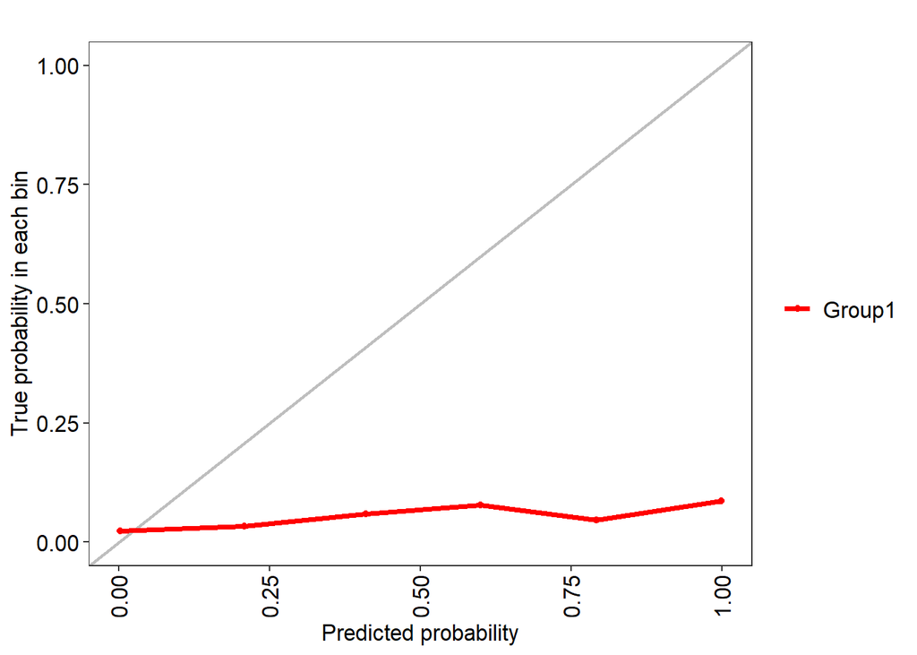

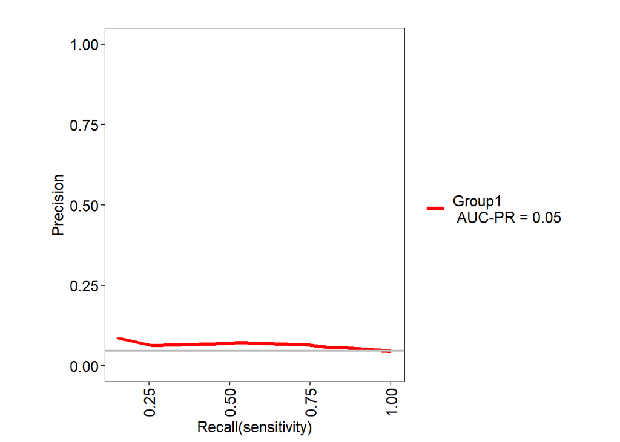

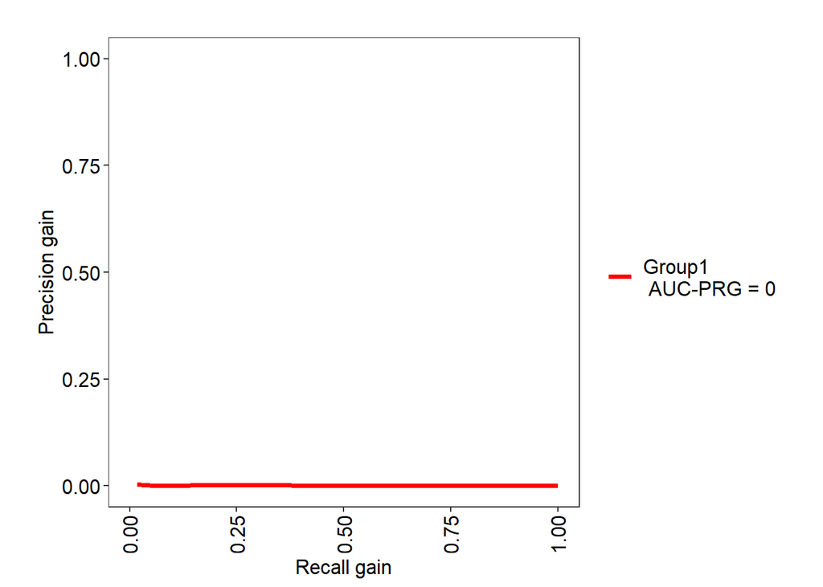

```
## Group1 Optimal Informedness = 0.225102490667197
```

```
## Group1 AUC-ROC = 0.62
```

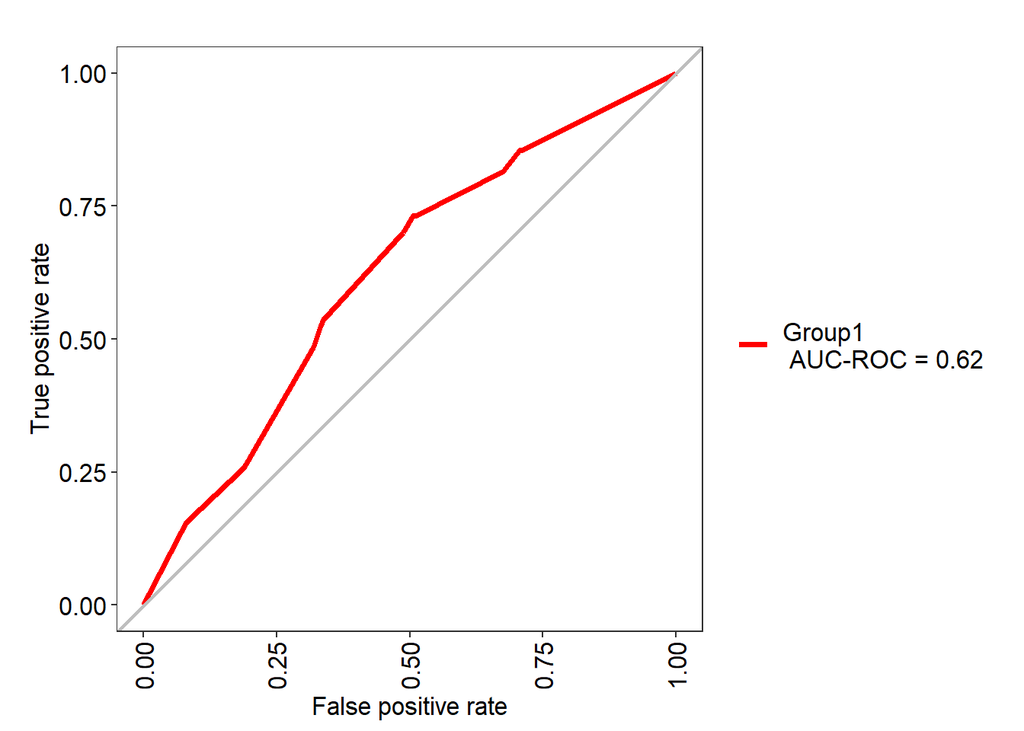